# Loan Data Invistigation Report

## Introduction

> In this analysis, we explore loan data from Prosper. This data set contains 113,937 loans with 81 variables on each loan, including loan amount, borrower rate (or interest rate), current loan status, borrower income, borrower employment status, borrower credit history, and the latest payment information.

### 1. General Scatter plot for some important features

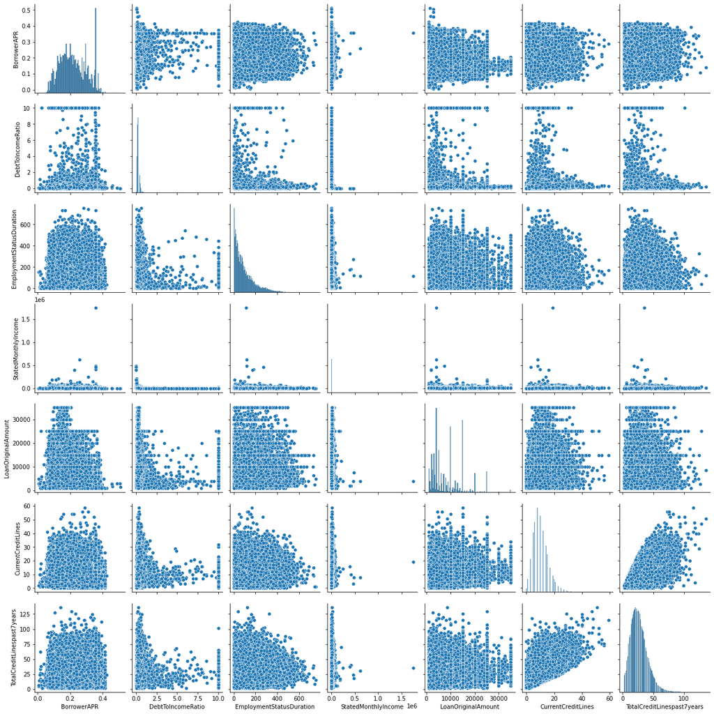

```python
g = snc.pairplot(data = df, vars = ['BorrowerAPR','DebtToIncomeRatio','EmploymentStatusDuration',\
                                    'StatedMonthlyIncome', 'LoanOriginalAmount','CurrentCreditLines',\
                                    'TotalCreditLinespast7years']);
```

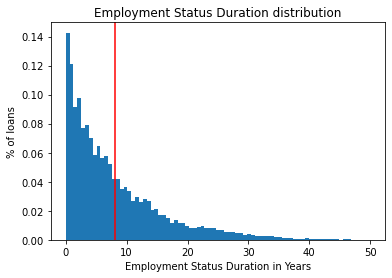

```python
#ditribution of Employment Status Duration
plt.hist(df.EmploymentStatusDuration/12, bins = np.linspace(0,50,80), density = True )
plt.title('Employment Status Duration distribution')
plt.axvline(x=df.EmploymentStatusDuration.mean()/12, color = 'r')
plt.ylabel('% of loans')
plt.xlabel('Employment Status Duration in Years');
```

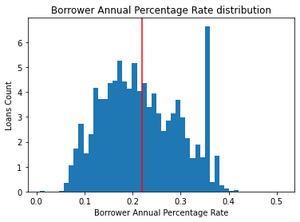

```python
#ditribution of Borrower Annual Percentage Rate
plt.hist(df.BorrowerAPR, bins=50, density = True )
plt.title('Borrower Annual Percentage Rate distribution')
plt.axvline(x=df.BorrowerAPR.mean(), color = 'r')
plt.ylabel('Loans Count')
plt.xlabel('Borrower Annual Percentage Rate');
```

> **Insight**: BorrowerAPR is almost normaly distributed.

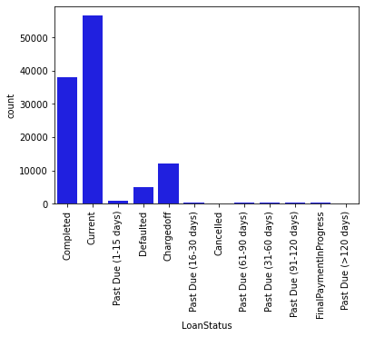

```python
#ditribution of loan status
snc.countplot(data=df, x='LoanStatus', color='blue');
plt.xticks(rotation=90);
```

### 2. How Borrower Annual Percentage Rate fluctuate over the years?

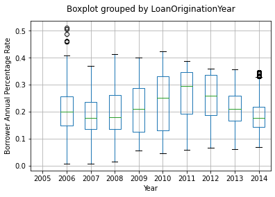

```python
df.boxplot(by="LoanOriginationYear", column="BorrowerAPR")
plt.ylabel('Borrower Annual Percentage Rate')
plt.xlabel('Year')
plt.title('');
```

> **Insight**: There was an increase in loan rate after 2008, which is expected as recover action by the markt to the recession period, then it started to decline after 2011.

### 3. What are the main loan usages over the years?

[figure not shown]

```python
q2=snc.countplot(x="LoanOriginationYear", hue='loan_usage',
            alpha=0.8,data=df);
snc.set(rc={'figure.figsize':(15,10)});
q2.set_title("Loan Usage distribution for every year",fontsize=15,loc='center');
q2.set_xlabel("Loan Year",fontsize=12);
q2.set_ylabel("Loan Count",fontsize=12);
```

> **Insight**: We can see debt consolidation category started to spike after 2008.

### 4. How Borrower APR affects Loan Status?

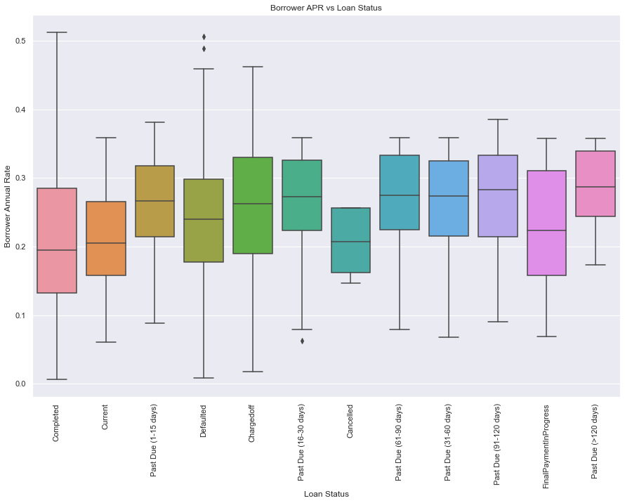

```python
ax = snc.boxplot(x='LoanStatus', y="BorrowerAPR", data=df)
plt.title('Borrower APR vs Loan Status')
plt.ylabel('Borrower Annual Rate')
plt.xlabel('Loan Status')
plt.xticks(rotation=90);
```

> **Insight**: We can see that bad loan statuses (Chargedoff, Defaulted, Past Due) have higher APR compared to the good loan statuses (Completed, Current, FinalPaymentInProgress).

### 5. How Debt to Income Ratio affects Loan Status?

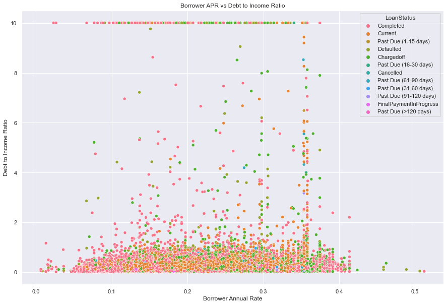

```python
ax = snc.scatterplot(x="BorrowerAPR", y='DebtToIncomeRatio', hue='LoanStatus', data=df)
plt.xlabel('Borrower Annual Rate')
plt.ylabel('Debt to Income Ratio')
plt.title('Borrower APR vs Debt to Income Ratio');
```

## Conclusions

> **2**- We can see debt consolidation category started to spike after 2008.

> **3**- There was an increase in loan rate after 2008, which is expected as recover action by the markt to the recession period, then it started to decline after 2011.